# Prosper's Loan Dataset

## Introduction

The dataset describes the loan data from Prosper. Variables include loan amount, interest rate, income, status of loan, occupation amongst other variables and these variables are described in details below;

1. ListingKey - Unique key for each listing, same value as the 'key' used in the listing object in the API.
2. ListingNumber - The number that uniquely identifies the listing to the public as displayed on the website.
3. ListingCreationDate - The date the listing was created.
4. CreditGrade - The Credit rating that was assigned at the time the listing went live. Applicable for listings pre-2009 period and will only be populated for those listings.
5. Term - The length of the loan expressed in months.
6. LoanStaus - The current status of the loan: Cancelled, Chargedoff, Completed, Current, Defaulted, FinalPaymentInProgress, PastDue. The PastDue status will be accompanied by a delinquency bucket.
7. ClosedDate - Closed date is applicable for Cancelled, Completed, Chargedoff and Defaulted loan statuses.
8. BorrowerAPR - The Borrower's Annual Percentage Rate (APR) for the loan.
9. BorrowerRate - The Borrower's interest rate for this loan.
10. LenderYield - The Lender yield on the loan. Lender yield is equal to the interest rate on the loan less the servicing fee.
11. EstimatedEffectiveYield - Effective yield is equal to the borrower interest rate (i) minus the servicing fee rate, (ii) minus estimated uncollected interest on charge-offs, (iii) plus estimated collected late fees. Applicable for loans originated after July 2009.
12. EstimatedLoss - Estimated loss is the estimated principal loss on charge-offs. Applicable for loans originated after July 2009.
13. EstimatedReturn - The estimated return assigned to the listing at the time it was created. Estimated return is the difference between the Estimated Effective Yield and the Estimated Loss Rate. Applicable for loans originated after July 2009.
14. PropserRating (Numeric) - The Prosper Rating assigned at the time the listing was created: 0 - N/A, 1 - HR, 2 - E, 3 - D, 4 - C, 5 - B, 6 - A, 7 - AA. Applicable for loans originated after July 2009.
15. ProsperRating (Alpha) - The Prosper Rating assigned at the time the listing was created between AA - HR. Applicable for loans originated after July 2009.
16. ProsperScore - A custom risk score built using historical Prosper data. The score ranges from 1-10, with 10 being the best, or lowest risk score. Applicable for loans originated after July 2009.
17. ListingCategory - The category of the listing that the borrower selected when posting their listing: 0 - Not Available, 1 - Debt Consolidation, 2 - Home Improvement, 3 - Business, 4 - Personal Loan, 5 - Student Use, 6 - Auto, 7- Other, 8 - Baby&Adoption, 9 - Boat, 10 - Cosmetic Procedure, 11 - Engagement Ring, 12 - Green Loans, 13 - Household Expenses, 14 - Large Purchases, 15 - Medical/Dental, 16 - Motorcycle, 17 - RV, 18 - Taxes, 19 - Vacation, 20 - Wedding Loans
18. BorrowerState - The two letter abbreviation of the state of the address of the borrower at the time the Listing was created.
19. Occupation - The Occupation selected by the Borrower at the time they created the listing.
20. EmploymentStatus - The employment status of the borrower at the time they posted the listing.
21. EmploymentStatusDuration - The length in months of the employment status at the time the listing was created.
22. IsBorrowerHomeowner - A Borrower will be classified as a homowner if they have a mortgage on their credit profile or provide documentation confirming they are a homeowner.
23. CurrentlyInGroup - Specifies whether or not the Borrower was in a group at the time the listing was created.
24. GroupKey - The Key of the group in which the Borrower is a member of. Value will be null if the borrower does not have a group affiliation.
25. DateCreditPulled - The date the credit profile was pulled.
26. CreditScoreRangeLower - The lower value representing the range of the borrower's credit score as provided by a consumer credit rating agency.
27. CreditScoreRangeUpper - The upper value representing the range of the borrower's credit score as provided by a consumer credit rating agency.
28. FirstRecordedCreditLine - The date the first credit line was opened.
29. CurrentCreditLines - Number of current credit lines at the time the credit profile was pulled.
30. OpenCreditLines - Number of open credit lines at the time the credit profile was pulled.
31. TotalCreditLinespast7years - Number of credit lines in the past seven years at the time the credit profile was pulled.
32. OpenRevolvingAccounts - Number of open revolving accounts at the time the credit profile was pulled.
33. OpenRevolvingMonthlyPayment - Monthly payment on revolving accounts at the time the credit profile was pulled.
34. InquiriesLast6Months - Number of inquiries in the past six months at the time the credit profile was pulled.
35. TotalInquiries - Total number of inquiries at the time the credit profile was pulled.
36. CurrentDelinquencies - Number of accounts delinquent at the time the credit profile was pulled.
37. AmountDelinquent - Dollars delinquent at the time the credit profile was pulled.
38. DelinquenciesLast7Years - Number of delinquencies in the past 7 years at the time the credit profile was pulled.
39. PublicRecordsLast10Years - Number of public records in the past 10 years at the time the credit profile was pulled.
40. PublicRecordsLast12Months - Number of public records in the past 12 months at the time the credit profile was pulled.
41. RevolvingCreditBalance - Dollars of revolving credit at the time the credit profile was pulled.
42. BankcardUtilization - The percentage of available revolving credit that is utilized at the time the credit profile was pulled.
43. AvailableBankcardCredit - The total available credit via bank card at the time the credit profile was pulled.
44. TotalTrades - Number of trade lines ever opened at the time the credit profile was pulled.
45. TradesNeverDelinquent - Number of trades that have never been delinquent at the time the credit profile was pulled.
46. TradesOpenedLast6Months - Number of trades opened in the last 6 months at the time the credit profile was pulled.
47. DebtToIncomeRatio - The debt to income ratio of the borrower at the time the credit profile was pulled. This value is Null if the debt to income ratio is not available. This value is capped at 10.01 (any debt to income ratio larger than 1000% will be returned as 1001%).
48. IncomeRange - The income range of the borrower at the time the listing was created.
49. IncomeVerifiable - The borrower indicated they have the required documentation to support their income.
50. StatedMonthlyIncome - The monthly income the borrower stated at the time the listing was created.
51. LoanKey - Unique key for each loan. This is the same key that is used in the API.
52. TotalProsperLoans - Number of Prosper loans the borrower at the time they created this listing. This value will be null if the borrower had no prior loans.
53. TotalProsperPaymentsBilled - Number of on time payments the borrower made on Prosper loans at the time they created this listing. This value will be null if the borrower had no prior loans.
54. OnTimeProsperPayments - Number of on time payments the borrower had made on Prosper loans at the time they created this listing. This value will be null if the borrower has no prior loans.
55. ProsperPaymentsLessThanOneMonthLate - Number of payments the borrower made on Prosper loans that were less than one month late at the time they created this listing. This value will be null if the borrower had no prior loans.
56. ProsperPaymentsOneMonthPlusLate - Number of payments the borrower made on Prosper loans that were greater than one month late at the time they created this listing. This value will be null if the borrower had no prior loans.
57. ProsperPrincipalBorrowed - Total principal borrowed on Prosper loans at the time the listing was created. This value will be null if the borrower had no prior loans.
58. ProsperPrincipalOutstanding - Principal outstanding on Prosper loans at the time the listing was created. This value will be null if the borrower had no prior loans.
59. ScorexChangeAtTimeOfListing - Borrower's credit score change at the time the credit profile was pulled. This will be the change relative to the borrower's last Prosper loan. This value will be null if the borrower had no prior loans.
60. LoanCurrentDaysDelinquent - The number of days delinquent.
61. LoanFirstDefaultedCycleNumber - The cycle the loan was charged off. If the loan has not charged off the value will be null.
62. LoanMonthsSinceOrigination - Number of months since the loan originated.
63. LoanNumber - Unique numeric value associated with the loan.
64. LoanOriginalAmount - The origination amount of the loan.
65. LoanOriginationDate - The date the loan was originated.
66. LoanOriginationQuarter - The quarter in which the loan was originated.
67. MemberKey - The unique key that is associated with the borrower. This is the same identifier that is used in the API member object.
68. MonthlyLoanPayment - The scheduled monthly loan payment.
69. LP_CustomerPayments - Pre charge-off cumulative gross payments made by the borrower on the loan. If the loan has charged off, this value will exclude any recoveries.
70. LP_CustomerPrincipalPayments - Pre charge-off cumulative principal payments made by the borrower on the loan. If the loan has charged off, this value will exclude any recoveries.
71. LP_InterestandFees - Pre charge-off cumulative interest and fees paid by the borrower. If the loan has charged off, this value will exclude any recoveries.
72. LP_ServiceFees - Cumulative service fees paid by the investors who have invested in the loan.
73. LP_CollectionFees - Cumulative collection fees paid by the investors who have invested in the loan.
74. LP_GrossPrincipalLoss - The gross charged off amount of the loan.
75. LP_NetPrincipalLoss - The principal that remains uncollected after any recoveries.
76. LP_NonPrincipalRecoverypayments - The interest and fee component of any recovery payments. The current payment policy applies payments in the following order: Fees, interest, principal.
77. PercentFunded - Percent the listing was funded.
78. Recommendations - Number of recommendations the borrower had at the time the listing was created.
79. InvestmentFromFriendsCount - Number of friends that made an investment in the loan.
80. InvestmentFromFriendsAmount - Dollar amount of investments that were made by friends.
81. Investors - The number of investors that funded the loan.

NOTE

- The variables above is a combination of numerical and categorical variable
- Not all the variables described above will be used for the project.

## Preliminary Wrangling

```python
# import all packages and set plots to be embedded inline
import numpy as np
import pandas as pd
import matplotlib.pyplot as plt
import seaborn as sb

%matplotlib inline
```

```python
# Setting the display option to ensure the entire column on the dataframe can be viewed

pd.set_option('display.max_columns', None)
```

```python
# loading the dataset and viewing the 1st 10 rows of the dataset

loan = pd.read_csv('prosperLoanData.csv')
loan.head(10)
```

|  | ListingKey | ListingNumber | ListingCreationDate | CreditGrade | Term | LoanStatus | ClosedDate | BorrowerAPR | BorrowerRate | LenderYield | EstimatedEffectiveYield | EstimatedLoss | EstimatedReturn | ProsperRating (numeric) | ProsperRating (Alpha) | ProsperScore | ListingCategory (numeric) | BorrowerState | Occupation | EmploymentStatus | EmploymentStatusDuration | IsBorrowerHomeowner | CurrentlyInGroup | GroupKey | DateCreditPulled | CreditScoreRangeLower | CreditScoreRangeUpper | FirstRecordedCreditLine | CurrentCreditLines | … |
| --- | --- | --- | --- | --- | --- | --- | --- | --- | --- | --- | --- | --- | --- | --- | --- | --- | --- | --- | --- | --- | --- | --- | --- | --- | --- | --- | --- | --- | --- | --- |
| 0 | 1021339766868145413AB3B | 193129 | 2007-08-26 19:09:29.263000000 | C | 36 | Completed | 2009-08-14 00:00:00 | 0.16516 | 0.1580 | 0.1380 | NaN | NaN | NaN | NaN | NaN | NaN | 0 | CO | Other | Self-employed | 2.0 | True | True | NaN | 2007-08-26 18:41:46.780000000 | 640.0 | 659.0 | 2001-10-11 00:00:00 | 5.0 | … |
| 1 | 10273602499503308B223C1 | 1209647 | 2014-02-27 08:28:07.900000000 | NaN | 36 | Current | NaN | 0.12016 | 0.0920 | 0.0820 | 0.07960 | 0.0249 | 0.05470 | 6.0 | A | 7.0 | 2 | CO | Professional | Employed | 44.0 | False | False | NaN | 2014-02-27 08:28:14 | 680.0 | 699.0 | 1996-03-18 00:00:00 | 14.0 | … |
| 2 | 0EE9337825851032864889A | 81716 | 2007-01-05 15:00:47.090000000 | HR | 36 | Completed | 2009-12-17 00:00:00 | 0.28269 | 0.2750 | 0.2400 | NaN | NaN | NaN | NaN | NaN | NaN | 0 | GA | Other | Not available | NaN | False | True | 783C3371218786870A73D20 | 2007-01-02 14:09:10.060000000 | 480.0 | 499.0 | 2002-07-27 00:00:00 | NaN | … |
| 3 | 0EF5356002482715299901A | 658116 | 2012-10-22 11:02:35.010000000 | NaN | 36 | Current | NaN | 0.12528 | 0.0974 | 0.0874 | 0.08490 | 0.0249 | 0.06000 | 6.0 | A | 9.0 | 16 | GA | Skilled Labor | Employed | 113.0 | True | False | NaN | 2012-10-22 11:02:32 | 800.0 | 819.0 | 1983-02-28 00:00:00 | 5.0 | … |
| 4 | 0F023589499656230C5E3E2 | 909464 | 2013-09-14 18:38:39.097000000 | NaN | 36 | Current | NaN | 0.24614 | 0.2085 | 0.1985 | 0.18316 | 0.0925 | 0.09066 | 3.0 | D | 4.0 | 2 | MN | Executive | Employed | 44.0 | True | False | NaN | 2013-09-14 18:38:44 | 680.0 | 699.0 | 2004-02-20 00:00:00 | 19.0 | … |
| 5 | 0F05359734824199381F61D | 1074836 | 2013-12-14 08:26:37.093000000 | NaN | 60 | Current | NaN | 0.15425 | 0.1314 | 0.1214 | 0.11567 | 0.0449 | 0.07077 | 5.0 | B | 10.0 | 1 | NM | Professional | Employed | 82.0 | True | False | NaN | 2013-12-14 08:26:40 | 740.0 | 759.0 | 1973-03-01 00:00:00 | 21.0 | … |
| 6 | 0F0A3576754255009D63151 | 750899 | 2013-04-12 09:52:56.147000000 | NaN | 36 | Current | NaN | 0.31032 | 0.2712 | 0.2612 | 0.23820 | 0.1275 | 0.11070 | 2.0 | E | 2.0 | 1 | KS | Sales - Retail | Employed | 172.0 | False | False | NaN | 2013-04-12 09:52:53 | 680.0 | 699.0 | 2000-09-29 00:00:00 | 10.0 | … |
| 7 | 0F1035772717087366F9EA7 | 768193 | 2013-05-05 06:49:27.493000000 | NaN | 36 | Current | NaN | 0.23939 | 0.2019 | 0.1919 | 0.17830 | 0.0799 | 0.09840 | 4.0 | C | 4.0 | 2 | CA | Laborer | Employed | 103.0 | False | False | NaN | 2013-05-05 06:49:25 | 700.0 | 719.0 | 1999-02-25 00:00:00 | 6.0 | … |
| 8 | 0F043596202561788EA13D5 | 1023355 | 2013-12-02 10:43:39.117000000 | NaN | 36 | Current | NaN | 0.07620 | 0.0629 | 0.0529 | 0.05221 | 0.0099 | 0.04231 | 7.0 | AA | 9.0 | 7 | IL | Food Service | Employed | 269.0 | True | False | NaN | 2013-12-02 10:43:39 | 820.0 | 839.0 | 1993-04-01 00:00:00 | 17.0 | … |
| 9 | 0F043596202561788EA13D5 | 1023355 | 2013-12-02 10:43:39.117000000 | NaN | 36 | Current | NaN | 0.07620 | 0.0629 | 0.0529 | 0.05221 | 0.0099 | 0.04231 | 7.0 | AA | 11.0 | 7 | IL | Food Service | Employed | 269.0 | True | False | NaN | 2013-12-02 10:43:39 | 820.0 | 839.0 | 1993-04-01 00:00:00 | 17.0 | … |

```python
# Understanding the shape of the dataset

loan.shape
```

```
(113937, 81)
```

```python
# A highlevel overview of the structure of the dataset. This reveals information such as the data types, the count of each variable
# and the number of non-null numbers


loan.info()
```

```
<class 'pandas.core.frame.DataFrame'>
RangeIndex: 113937 entries, 0 to 113936
Data columns (total 81 columns):
 #   Column                               Non-Null Count   Dtype
---  ------                               --------------   -----
 0   ListingKey                           113937 non-null  object
 1   ListingNumber                        113937 non-null  int64
 2   ListingCreationDate                  113937 non-null  object
 3   CreditGrade                          28953 non-null   object
 4   Term                                 113937 non-null  int64
 5   LoanStatus                           113937 non-null  object
 6   ClosedDate                           55089 non-null   object
 7   BorrowerAPR                          113912 non-null  float64
 8   BorrowerRate                         113937 non-null  float64
 9   LenderYield                          113937 non-null  float64
```

[output cut: 73 more lines]

```python
#Statistical description of the dataset

loan.describe()
```

|  | ListingNumber | Term | BorrowerAPR | BorrowerRate | LenderYield | EstimatedEffectiveYield | EstimatedLoss | EstimatedReturn | ProsperRating (numeric) | ProsperScore | ListingCategory (numeric) | EmploymentStatusDuration | CreditScoreRangeLower | CreditScoreRangeUpper | CurrentCreditLines | OpenCreditLines | TotalCreditLinespast7years | OpenRevolvingAccounts | OpenRevolvingMonthlyPayment | InquiriesLast6Months | TotalInquiries | CurrentDelinquencies | AmountDelinquent | DelinquenciesLast7Years | PublicRecordsLast10Years | PublicRecordsLast12Months | RevolvingCreditBalance | BankcardUtilization | AvailableBankcardCredit | … |
| --- | --- | --- | --- | --- | --- | --- | --- | --- | --- | --- | --- | --- | --- | --- | --- | --- | --- | --- | --- | --- | --- | --- | --- | --- | --- | --- | --- | --- | --- | --- |
| count | 1.139370e+05 | 113937.000000 | 113912.000000 | 113937.000000 | 113937.000000 | 84853.000000 | 84853.000000 | 84853.000000 | 84853.000000 | 84853.000000 | 113937.000000 | 106312.000000 | 113346.000000 | 113346.000000 | 106333.000000 | 106333.000000 | 113240.000000 | 113937.00000 | 113937.000000 | 113240.000000 | 112778.000000 | 113240.000000 | 106315.000000 | 112947.000000 | 113240.000000 | 106333.000000 | 1.063330e+05 | 106333.000000 | 106393.000000 | … |
| mean | 6.278857e+05 | 40.830248 | 0.218828 | 0.192764 | 0.182701 | 0.168661 | 0.080306 | 0.096068 | 4.072243 | 5.950067 | 2.774209 | 96.071582 | 685.567731 | 704.567731 | 10.317192 | 9.260164 | 26.754539 | 6.96979 | 398.292161 | 1.435085 | 5.584405 | 0.592052 | 984.507059 | 4.154984 | 0.312646 | 0.015094 | 1.759871e+04 | 0.561309 | 11210.225447 | … |
| std | 3.280762e+05 | 10.436212 | 0.080364 | 0.074818 | 0.074516 | 0.068467 | 0.046764 | 0.030403 | 1.673227 | 2.376501 | 3.996797 | 94.480605 | 66.458275 | 66.458275 | 5.457866 | 5.022644 | 13.637871 | 4.63097 | 447.159711 | 2.437507 | 6.429946 | 1.978707 | 7158.270157 | 10.160216 | 0.727868 | 0.154092 | 3.293640e+04 | 0.317918 | 19818.361309 | … |
| min | 4.000000e+00 | 12.000000 | 0.006530 | 0.000000 | -0.010000 | -0.182700 | 0.004900 | -0.182700 | 1.000000 | 1.000000 | 0.000000 | 0.000000 | 0.000000 | 19.000000 | 0.000000 | 0.000000 | 2.000000 | 0.00000 | 0.000000 | 0.000000 | 0.000000 | 0.000000 | 0.000000 | 0.000000 | 0.000000 | 0.000000 | 0.000000e+00 | 0.000000 | 0.000000 | … |
| 25% | 4.009190e+05 | 36.000000 | 0.156290 | 0.134000 | 0.124200 | 0.115670 | 0.042400 | 0.074080 | 3.000000 | 4.000000 | 1.000000 | 26.000000 | 660.000000 | 679.000000 | 7.000000 | 6.000000 | 17.000000 | 4.00000 | 114.000000 | 0.000000 | 2.000000 | 0.000000 | 0.000000 | 0.000000 | 0.000000 | 0.000000 | 3.121000e+03 | 0.310000 | 880.000000 | … |
| 50% | 6.005540e+05 | 36.000000 | 0.209760 | 0.184000 | 0.173000 | 0.161500 | 0.072400 | 0.091700 | 4.000000 | 6.000000 | 1.000000 | 67.000000 | 680.000000 | 699.000000 | 10.000000 | 9.000000 | 25.000000 | 6.00000 | 271.000000 | 1.000000 | 4.000000 | 0.000000 | 0.000000 | 0.000000 | 0.000000 | 0.000000 | 8.549000e+03 | 0.600000 | 4100.000000 | … |
| 75% | 8.926340e+05 | 36.000000 | 0.283810 | 0.250000 | 0.240000 | 0.224300 | 0.112000 | 0.116600 | 5.000000 | 8.000000 | 3.000000 | 137.000000 | 720.000000 | 739.000000 | 13.000000 | 12.000000 | 35.000000 | 9.00000 | 525.000000 | 2.000000 | 7.000000 | 0.000000 | 0.000000 | 3.000000 | 0.000000 | 0.000000 | 1.952100e+04 | 0.840000 | 13180.000000 | … |
| max | 1.255725e+06 | 60.000000 | 0.512290 | 0.497500 | 0.492500 | 0.319900 | 0.366000 | 0.283700 | 7.000000 | 11.000000 | 20.000000 | 755.000000 | 880.000000 | 899.000000 | 59.000000 | 54.000000 | 136.000000 | 51.00000 | 14985.000000 | 105.000000 | 379.000000 | 83.000000 | 463881.000000 | 99.000000 | 38.000000 | 20.000000 | 1.435667e+06 | 5.950000 | 646285.000000 | … |

```python
loan_drop = ['Listingkey', 'ProsperRating']
```

```python
loan[['LoanOriginalAmount', 'Term']].describe()
```

|  | LoanOriginalAmount | Term |
| --- | --- | --- |
| count | 113937.00000 | 113937.000000 |
| mean | 8337.01385 | 40.830248 |
| std | 6245.80058 | 10.436212 |
| min | 1000.00000 | 12.000000 |
| 25% | 4000.00000 | 36.000000 |
| 50% | 6500.00000 | 36.000000 |
| 75% | 12000.00000 | 36.000000 |
| max | 35000.00000 | 60.000000 |

### What is the structure of your dataset?

> The dataset has 113937 different loan records and 81 information for each loan record (i.e 113,937 rows and 81 columns)

### What is/are the main feature(s) of interest in your dataset?

> The following features are of interest to me as a businessman becuase I want to be certian that I will get back my capital with good interest;
> 1. LoanStatus - The current status of the loan: Cancelled, Chargedoff, Completed, Current, Defaulted, FinalPaymentInProgress, PastDue. The PastDue status will be accompanied by a delinquency bucket.
> 2. EstimatedReturn - The estimated return assigned to the listing at the time it was created. Estimated return is the difference between the Estimated Effective Yield and the Estimated Loss Rate. Applicable for loans originated after July 2009.

### What features in the dataset do you think will help support your investigation into your feature(s) of interest?

I believe the following dependent features will support investigation into my areas of interest;

1. Term - The length of the loan expressed in months.
2. LoanStatus The current status of the loan: Cancelled, Chargedoff, Completed, Current, Defaulted, FinalPaymentInProgress, PastDue. The PastDue status will be accompanied by a delinquency bucket..
3. BorrowerRate - The Borrower's interest rate for this loan.
4. EmploymentStatus - The employment status of the borrower at the time they posted the listing.
5. StatedMonthlyIncome - The monthly income the borrower stated at the time the listing was created.
6. ProsperScore - A custom risk score built using historical Prosper data. The score ranges from 1-10, with 10 being the best, or lowest risk score. Applicable for loans originated after July 2009.
7. TotalProsperLoans - Number of Prosper loans the borrower at the time they created this listing. This value will be null if the borrower had no prior loans.
8. BorrowerAPR - The Borrower's Annual Percentage Rate (APR) for the loan.
9. IncomeRange - The income range of the borrower at the time the listing was created.
10. ProsperRating (Alpha) - The Prosper Rating assigned at the time the listing was created between AA - HR. Applicable for loans originated after July 2009.
11. LoanOriginalAmount - The origination amount of the loan.
12. EstimatedReturn - The estimated return assigned to the listing at the time it was created. Estimated return is the difference between the Estimated Effective Yield and the Estimated Loss Rate. Applicable for loans originated after July 2009.

#### Before i start exploration, i will like to capitalize all the column headers for easy data entry

```python
# Column headers capitalization

loan.columns = loan.columns.str.capitalize()
loan.columns
```

```
Index(['Listingkey', 'Listingnumber', 'Listingcreationdate', 'Creditgrade',
       'Term', 'Loanstatus', 'Closeddate', 'Borrowerapr', 'Borrowerrate',
       'Lenderyield', 'Estimatedeffectiveyield', 'Estimatedloss',
       'Estimatedreturn', 'Prosperrating (numeric)', 'Prosperrating (alpha)',
       'Prosperscore', 'Listingcategory (numeric)', 'Borrowerstate',
       'Occupation', 'Employmentstatus', 'Employmentstatusduration',
       'Isborrowerhomeowner', 'Currentlyingroup', 'Groupkey',
       'Datecreditpulled', 'Creditscorerangelower', 'Creditscorerangeupper',
       'Firstrecordedcreditline', 'Currentcreditlines', 'Opencreditlines',
       'Totalcreditlinespast7years', 'Openrevolvingaccounts',
       'Openrevolvingmonthlypayment', 'Inquirieslast6months', 'Totalinquiries',
       'Currentdelinquencies', 'Amountdelinquent', 'Delinquencieslast7years',
       'Publicrecordslast10years', 'Publicrecordslast12months',
       'Revolvingcreditbalance', 'Bankcardutilization',
       'Availablebankcardcredit', 'Totaltrades',
       'Tradesneverdelinquent (percentage)', 'Tradesopenedlast6months',
       'Debttoincomeratio', 'Incomerange', 'Incomeverifiable',
       'Statedmonthlyincome', 'Loankey', 'Totalprosperloans',
       'Totalprosperpaymentsbilled', 'Ontimeprosperpayments',
       'Prosperpaymentslessthanonemonthlate',
       'Prosperpaymentsonemonthpluslate', 'Prosperprincipalborrowed',
       'Prosperprincipaloutstanding', 'Scorexchangeattimeoflisting',
       'Loancurrentdaysdelinquent', 'Loanfirstdefaultedcyclenumber',
       'Loanmonthssinceorigination', 'Loannumber', 'Loanoriginalamount',
       'Loanoriginationdate', 'Loanoriginationquarter', 'Memberkey',
       'Monthlyloanpayment', 'Lp_customerpayments',
       'Lp_customerprincipalpayments', 'Lp_interestandfees', 'Lp_servicefees',
       'Lp_collectionfees', 'Lp_grossprincipalloss', 'Lp_netprincipalloss',
       'Lp_nonprincipalrecoverypayments', 'Percentfunded', 'Recommendations',
       'Investmentfromfriendscount', 'Investmentfromfriendsamount',
       'Investors'],
      dtype='object')
```

## Univariate Exploration

> In this section, individual assessment of some of the features will be done to give an insight of the data set. Additional assessment on any variable that requires further exploration will be done

### 1. Term

```python
#Statistical overview of the Term variable

print(loan['Term'].unique())
loan['Term'].describe()
```

```
[36 60 12]
```

```
count    113937.000000
mean         40.830248
std          10.436212
min          12.000000
25%          36.000000
50%          36.000000
75%          36.000000
max          60.000000
Name: Term, dtype: float64
```

#### From the above, we can deduce that

- The variable type is an integer and thus numerical
- There are only 3 unique variables
- A pie chart will be sufficient since there are only 3 unique variable

#### How is loan term distributed by month?

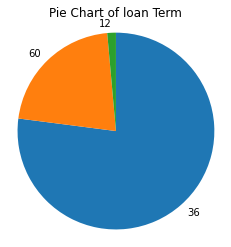

```python
# Plotting a Pie Chart

term_count = loan['Term'].value_counts()
term_count_index = loan['Term'].value_counts().index

plt.pie(term_count, labels = term_count_index, startangle = 90, counterclock = False)
plt.title('Pie Chart of loan Term')
plt.axis('square');
```

#### Observation: It evident that loan term of 36 months has the highest frequency (more than 75% of total loan term) followed by 60 months loan and the least is 12 months loan term

### 2. Loan status

```python
# Investigating the unique categories

loan['Loanstatus'].unique()
```

```
array(['Completed', 'Current', 'Past Due (1-15 days)', 'Defaulted',
       'Chargedoff', 'Past Due (16-30 days)', 'Cancelled',
       'Past Due (61-90 days)', 'Past Due (31-60 days)',
       'Past Due (91-120 days)', 'FinalPaymentInProgress',
       'Past Due (>120 days)'], dtype=object)
```

#### From the above, we can deduce the following;

- The variable is categorical
- Variable is in the apropriate data type (object)
- A horizontal bar chart will be apropritate to visualize the variable
- Multiple category for Past Due values. To lump everything into one for easy classification

#### How is loan status distributed?

```python
# Lump all past due categories into one being 'Pastdue'
# Replace FinalPaymentInProgress

loan['Loanstatus'] = loan['Loanstatus'].replace(['Past Due (1-15 days)', 'Past Due (16-30 days)',
                                                 'Past Due (61-90 days)', 'Past Due (31-60 days)',
                                                 'Past Due (91-120 days)', 'Past Due (>120 days)'],
                                                'Pastdue').str.replace('FinalPaymentInProgress', 'Finalpayment')
loan['Loanstatus'].unique()
```

```
array(['Completed', 'Current', 'Pastdue', 'Defaulted', 'Chargedoff',
       'Cancelled', 'Finalpayment'], dtype=object)
```

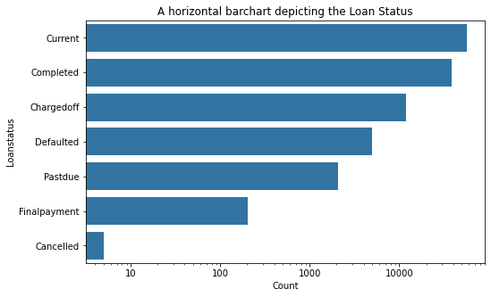

```python
# plotting a horizontal barchart

plt.figure(figsize = [8,5])
color_base = sb.color_palette()[0]

# Ordering the bars in decreasing order
orders = loan['Loanstatus'].value_counts().index
sb.countplot(data = loan, y = 'Loanstatus', color = color_base, order = orders);

# Scale Transformation
plt.xscale('log')
ticks = [10, 100, 1000, 10000]
label = ['{}'.format (v) for v in ticks]
plt.xticks(ticks, label)

# Labelling the chart
plt.xlabel('Count')
plt.ylabel('Loanstatus')
plt.title('A horizontal barchart depicting the Loan Status')
```

#### Observation: The current loan status has the highest frequency while cancelled loans are the least

### 3. Borrower Rate

```python
# Highlevel overview of the variable

print(loan['Borrowerrate'].nunique())
print(loan['Borrowerrate'].describe())
loan['Borrowerrate'].value_counts()
```

```
2294
count    113937.000000
mean          0.192764
std           0.074818
min           0.000000
25%           0.134000
50%           0.184000
75%           0.250000
max           0.497500
Name: Borrowerrate, dtype: float64
```

```
0.3177    3672
0.3500    1905
0.3199    1651
0.2900    1508
0.2699    1319
          ...
0.2201       1
0.0752       1
0.1416       1
0.2812       1
0.0739       1
Name: Borrowerrate, Length: 2294, dtype: int64
```

#### How does the borrower rate distribution look like?

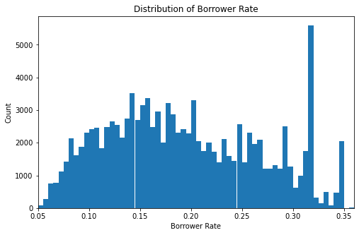

```python
bin2 = np.arange(0, loan['Borrowerrate'].max()+0.005, 0.005)

plt.figure(figsize = [8, 5])

plt.hist(data = loan, x = 'Borrowerrate', bins = bin2);
plt.xlabel('Borrower Rate')
plt.ylabel('Count');
plt.title('Distribution of Borrower Rate')
plt.xlim(0.05, 0.36);
```

#### Observation: The distribution is bimodial with a major peak around 0.32

### 4. Employment Status

```python
# Overview of key details of the variable

loan['Employmentstatus'].unique()
```

```
array(['Self-employed', 'Employed', 'Not available', 'Full-time', 'Other',
       nan, 'Not employed', 'Part-time', 'Retired'], dtype=object)
```

#### The above shows that;

- The variable is categorical
- A bar chart will be sufficient for data exploration

#### How does the total loan per employment status distribution look like?

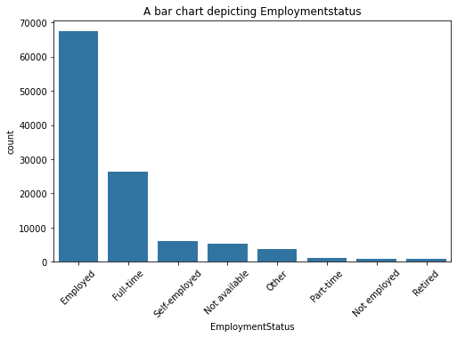

```python
# Plotting the bar

plt.figure(figsize = [8, 5])

base_color = sb.color_palette()[0]

orders = loan['Employmentstatus'].value_counts().index

sb.countplot(data = loan, x = 'Employmentstatus', color = base_color, order = orders);
plt.xlabel('EmploymentStatus')
plt.xticks(rotation = 45)
plt.title('A bar chart depicting Employmentstatus');
```

#### Observation: Loans from employed people have the highest frequency with over 65,000 counts followed by full-time and the least is from those that have retired.

### 5. Stated Monthly Income

```python
# Taking a statistical overview of the feature

loan.Statedmonthlyincome.describe()
```

```
count    1.139370e+05
mean     5.608026e+03
std      7.478497e+03
min      0.000000e+00
25%      3.200333e+03
50%      4.666667e+03
75%      6.825000e+03
max      1.750003e+06
Name: Statedmonthlyincome, dtype: float64
```

#### The following can be deduced from the above statistical overview

- The feature is numerical and data type is float
- The max value appears to be an outlier
- A histogram will be an appropriate exploration technique because of the wide data distribution

#### How does the Stated Monthly Income distribution look like?

```python
# Getting the statistical distribution

loan['Statedmonthlyincome'].describe()
```

```
count    1.139370e+05
mean     5.608026e+03
std      7.478497e+03
min      0.000000e+00
25%      3.200333e+03
50%      4.666667e+03
75%      6.825000e+03
max      1.750003e+06
Name: Statedmonthlyincome, dtype: float64
```

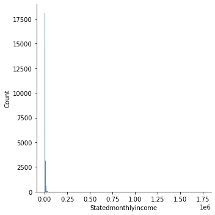

```python
# Creating the bins
bin_edges = np.arange(0, loan['Statedmonthlyincome'].max()+1000, 1000)

# plotting the hisytogram
sb.displot(data = loan, x = 'Statedmonthlyincome', bins = bin_edges);
```

#### The above histogram does not give any useful information due to the impact of the maximum value which is an outlier. This will be addressed by taking a log transformation of the scale as shown below.

#### Log Transformation

```
C:\Users\Azuka Ume\AppData\Local\Temp\ipykernel_8036\48674136.py:9: UserWarning: Attempted to set non-positive left xlim on a log-scaled axis.
Invalid limit will be ignored.
  plt.xlim(0, 50000);
```

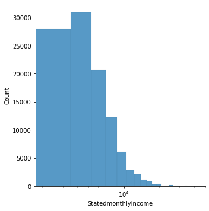

```python
sb.displot(data = loan, x = 'Statedmonthlyincome', bins = 1000)

plt.xscale('log');

ticks = [0, 10, 100, 1000, 10000, ]

plt.xticks(ticks)

plt.xlim(0, 50000);
```

#### Observations: The stated monthly income distribution is skewed to the right. It can be said that the mean and median distributions are to the right

### 6. Prosper Score

```python
# Assessing the Prosper score with different assessment tools

print(loan.Prosperscore.unique())

print(loan.Prosperscore.nunique())

print(loan.Prosperscore.dtype)
```

```
[nan  7.  9.  4. 10.  2. 11.  8.  5.  3.  6.  1.]
11
float64
```

#### From the above;

- There are 11 uniques values. From the definition of Prosper Score, the rating is 1 - 10 meaning that the 11th rating isn't needed and will therefore be dropped.
- The ratings are categorical but in float data type
- A bar chart will be an appropriate exploration tool

#### How is the total loan distributed per Prosper Score?

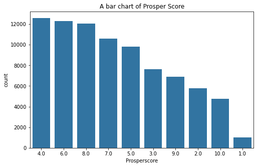

```python
#replacing the 11th rating with np.nan and dropping all null cell
loan['Prosperscore'] = loan['Prosperscore'].replace(11, np.nan).dropna()

#Plotting the histogram
plt.figure(figsize = [8, 5])
orders = loan['Prosperscore'].value_counts().index
sb.countplot(data = loan, x = 'Prosperscore', order = orders, color = base_color);
plt.title('A bar chart of Prosper Score');
```

#### Observations:

- A rating of 4.0 was the highest with followed very closely by 6.0 and 8.0 with all three ratings having counts = or > 12,000
- The least rating is 1.0 with count less than 2000 loans

### 7. Total Prosper Loans

```python
# Overview of the Total Prosper Loan feature

print(loan.Totalprosperloans.unique())

loan.Totalprosperloans.describe()
```

```
[nan  1.  3.  2.  4.  6.  5.  8.  7.  0.]
```

```
count    22085.000000
mean         1.421100
std          0.764042
min          0.000000
25%          1.000000
50%          1.000000
75%          2.000000
max          8.000000
Name: Totalprosperloans, dtype: float64
```

#### The above overview tells us that;

- The values appear numerical but in reality, they are categorical since it's grouping of the number of loans at the time of listing
- A bar chart will be an appropriate data exploration tool

#### What is the distribution of the Total Prosper Loans?

```
[nan  1.  3.  2.  4.  6.  5.  8.  7.  0.]
```

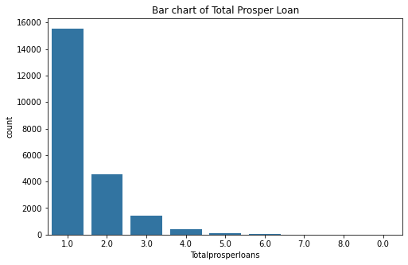

```python
# Drop null rows
loan['Totalprosperloans'] = loan['Totalprosperloans'].dropna()

# Number of unique values
print(loan['Totalprosperloans'].unique())

# Sorting values in increasing order
orders2 = loan['Totalprosperloans'].value_counts().index

plt.figure(figsize = [8, 5])
sb.countplot(data = loan, x = 'Totalprosperloans', order = orders2, color = base_color)
plt.title('Bar chart of Total Prosper Loan');
```

#### Observation: Borrowers with one (1) prosper loan had the highest frequency.

### 8. Borrower APR

```python
# Statistical overview of the feature

print(loan['Borrowerapr'].nunique())
print(loan['Borrowerapr'].describe())
loan['Borrowerapr'].value_counts()
```

```
6677
count    113912.000000
mean          0.218828
std           0.080364
min           0.006530
25%           0.156290
50%           0.209760
75%           0.283810
max           0.512290
Name: Borrowerapr, dtype: float64
```

```
0.35797    3672
0.35643    1644
0.37453    1260
0.30532     902
0.29510     747
           ...
0.37266       1
0.27518       1
0.18477       1
0.29961       1
0.19543       1
Name: Borrowerapr, Length: 6677, dtype: int64
```

#### What does the borrower APR distribution rate look like?

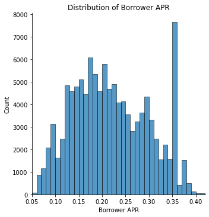

```python
# Plotting the histogram

plt.figure(figsize = [10, 7])

bin = np.arange(0, loan['Borrowerapr'].max()+0.01, 0.01)
sb.displot(data = loan, x = 'Borrowerapr', bins = bin);

plt.xlabel('Borrower APR')
plt.ylabel('Count')
plt.title('Distribution of Borrower APR')

plt.xlim(0.05, 0.42);
```

#### Observation: The distribution is bimodial with the major peak around 0.35

### 9. Income Range

```python
# Highlevel overview of the variable

print(loan['Incomerange'].nunique())

loan['Incomerange'].value_counts()
```

```
8
```

```
$25,000-49,999    32192
$50,000-74,999    31050
$100,000+         17337
$75,000-99,999    16916
Not displayed      7741
$1-24,999          7274
Not employed        806
$0                  621
Name: Incomerange, dtype: int64
```

#### The following can be deduced from the above;

- There are 8 unique values
- The variable is a string
- There are 3 sets of values which are invalid. The values are 'Not displayed', 'Not employed' and '$0' which will be replaced with np.nan and then dropped
- A bar chart will be used to visualize the distribution

#### What is the distribution of the loans per income range?

```python
# Replacing the invalid values

loan['Incomerange'] = loan['Incomerange'].replace(['Not displayed', 'Not employed', '$0'], np.nan)
loan['Incomerange'].value_counts()
```

```
$25,000-49,999    32192
$50,000-74,999    31050
$100,000+         17337
$75,000-99,999    16916
$1-24,999          7274
Name: Incomerange, dtype: int64
```

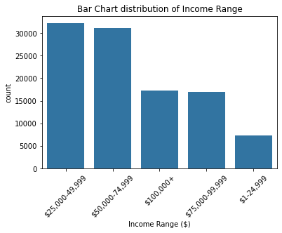

```python
#Plotting the bar chart

sb.countplot(data = loan, x = 'Incomerange', color = base_color);
plt.xticks(rotation = 45)
plt.xlabel('Income Range ($)')
plt.title('Bar Chart distribution of Income Range');
```

#### Observations:

- Income range $25k - $49.99K has the highest count. This is closely followed by $50k - $74.99k
- The income range with the least count is $1 - $24.99k with count of about 7,000 loans

### 10. Prosper Rating (alpha)

```python
# Overview of the feature

print(loan['Prosperrating (alpha)'].nunique())

print(loan['Prosperrating (alpha)'].unique())
```

```
7
[nan 'A' 'D' 'B' 'E' 'C' 'AA' 'HR']
```

#### From the above overview, we can deduce that;

- The feature is categorical
- There are 7 unique categories
- A bar chart will be an appropriate univariate tool
- Presnece of null rows which we'd have to drop before exploration

#### How does the Prosper rating (alpha) distribution look like?

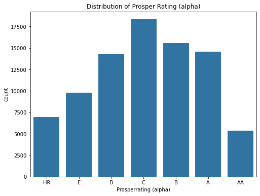

```python
# Dropping null cells
loan['Prosperrating (alpha)'].dropna()

# Plotting the bar chart
rating_cat = ['HR', 'E', 'D', 'C', 'B', 'A', 'AA']
rating_classes = pd.api.types.CategoricalDtype(ordered = True, categories = rating_cat)
loan['Prosperrating (alpha)'] = loan['Prosperrating (alpha)'].astype(rating_classes)

plt.figure(figsize = [8, 6])

sb.countplot(data = loan, x = 'Prosperrating (alpha)', color = base_color);
plt.title('Distribution of Prosper Rating (alpha)');
```

#### Observations:

- The distribution is unimodal
- Rating 'C' has the highest count while rating 'AA' has the least count

### 11. Loan Original Amount

```python
# Overview of the feature

print(loan['Loanoriginalamount'].nunique())

print(loan['Loanoriginalamount'].describe())
```

```
2468
count    113937.00000
mean       8337.01385
std        6245.80058
min        1000.00000
25%        4000.00000
50%        6500.00000
75%       12000.00000
max       35000.00000
Name: Loanoriginalamount, dtype: float64
```

#### The above overview shows that;

- The data is numerical and continuous
- There are 2,468 unique values
- A histogram will be an appropriate exploration tool for this feature
- Bins will be created between the minimum and maximum values

#### What is the distribution of the loan original amount at the time of the listing?

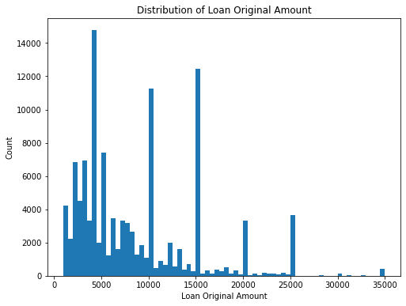

```python
# Plotting the histogram

bin5 = np.arange(1000, loan['Loanoriginalamount'].max()+500, 500)

plt.figure(figsize = [8, 6])

plt.hist(data = loan, x = 'Loanoriginalamount', bins = bin5, color = base_color);
plt.xlabel('Loan Original Amount')
plt.ylabel('Count')
plt.title('Distribution of Loan Original Amount');
```

#### Onservations:

- The distribution is multimodial with the highest peak between 2000 and 5000
- Other major peaks were observed at 10,000 and 15,000 with lesser peaks at 20,000 and 25,000

### 12. Estimated Return

```python
# High level overview

print(loan['Estimatedreturn'].nunique())
loan['Estimatedreturn'].describe()
```

```
1476
```

```
count    84853.000000
mean         0.096068
std          0.030403
min         -0.182700
25%          0.074080
50%          0.091700
75%          0.116600
max          0.283700
Name: Estimatedreturn, dtype: float64
```

#### The above shows that;

- The feature is numerical and continuous
- A histogram will be appropriate for assessing the distribution

#### What does the Estimated return distribution look like?

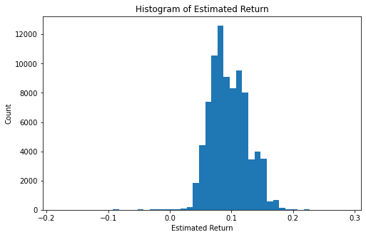

```python
#Plotting the Histogram

bin6 = np.arange(loan['Estimatedreturn'].min(), loan['Estimatedreturn'].max()+0.01, 0.01)

plt.figure(figsize = [8,5])
plt.hist(data = loan, x = 'Estimatedreturn', bins = bin6);
plt.xlabel('Estimated Return')
plt.ylabel('Count')
plt.title('Histogram of Estimated Return');
```

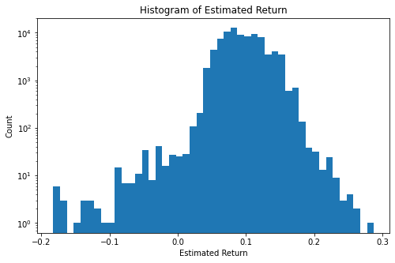

```python
# Count axis (Y Axis) tranformation for better exploration and clarity
plt.figure(figsize = [8,5])
plt.hist(data = loan, x = 'Estimatedreturn', bins = bin6);
plt.xlabel('Estimated Return')
plt.ylabel('Count')
plt.title('Histogram of Estimated Return');
plt.yscale('log');
```

#### Observations:

- The distribution is unimodal
- The distribution is skewed to the left

### Discuss the distribution(s) of your variable(s) of interest. Were there any unusual points? Did you need to perform any transformations?

> 1. Estimated Return - This variable is numerical and a histogram was used to assess the distibution. The initial plot was not clear and thus, a transformation was done on the y-axis for better exploration. There were presence of negative values which is not good for investment.
> 2. Loan Status - This variable is categorical and a bar chart was used for exploration. A significant portion of the loan were still active at the time of listing

### Of the features you investigated, were there any unusual distributions? Did you perform any operations on the data to tidy, adjust, or change the form of the data? If so, why did you do this?

> 1. Income Range - This feature is categorical as the groupings were in ranges. The feature was specific about borrowers with earnings and 3 groups without earnings were present. These groups were replaced with np.nan to tidy the data set and they were eventually dropped
> 2. Prosper Score - The definition of the Prosper Score speaks to ratings 1 - 10. The data provided has ratings up to 11 which implies that the 11th ratings are not valid. These were dropped becuase they were not needed.
> 3. Stated Monthly Income - The variable is a continuous numerical variable with wide value distribution. A histogram was used to explore the data set but the presence of an outlier (the max value) distorted the initial plot. Further investigation meant that a log transformation was done on the x-axis

## Bivariate Exploration

> To start this section of the project, i will like to explore the pairwise correlation between features in the data. This will be done based on the types of data types

### 1. QUANTITATIVE VS QUANTITATIVE

#### A. Borrower APR vs Borrower Rate

> What is the relationship between borrower apr and borrower rate?

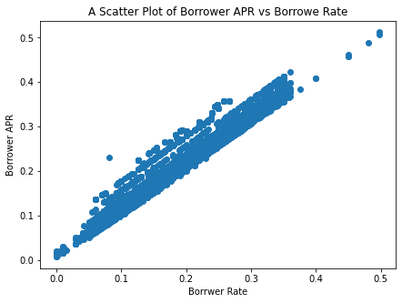

```python
plt.figure(figsize = [7,5])

plt.scatter(data = loan, x = 'Borrowerrate', y = 'Borrowerapr');
plt.xlabel('Borrwer Rate')
plt.ylabel('Borrower APR')
plt.title('A Scatter Plot of Borrower APR vs Borrowe Rate');
```

#### Observations:

- There is a direct relationship between borrower APR and borrower rate
- Borrower rate increases as borrower apr increases

#### B. Loan Original amount vs Borrower rate and Loan Original Amount vs Borrower APR

> What is the relationship of loan original amount with borrower rate and borrower apr?

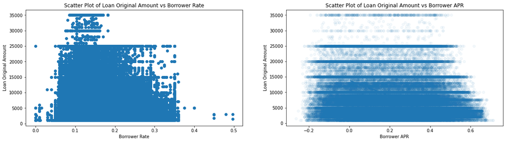

```python
plt.figure(figsize = [20, 5])

plt.subplot(1, 2, 1)
plt.scatter(data = loan, x = 'Borrowerrate', y = 'Loanoriginalamount');
plt.xlabel('Borrower Rate')
plt.ylabel('Loan Original Amount')
plt.title('Scatter Plot of Loan Original Amount vs Borrower Rate');

plt.subplot(1, 2, 2)
sb.regplot(data = loan, x = 'Borrowerapr', y = 'Loanoriginalamount', x_jitter = 0.3, scatter_kws = {'alpha':1/20});
plt.xlabel('Borrower APR')
plt.ylabel('Loan Original Amount')
plt.title('Scatter Plot of Loan Original Amount vs Borrower APR');
```

#### Observations:

- Loan Original Amount have similar relationship with both borrower rate and borrower APR
- There is no clear ralationship betweem these variables with little insight particularly from Loan original amount and borrower rate.
- The highest borrower rate 0f 0.5 was observed for loan amounts less than 5000. This loan data appears to be an outlier

### Correlation of Key Numeric Variables

> What is the relationship between Loanoriginalamount, Borrower apr, Borrower rate, Estimatedreturn and Stated monthly income?

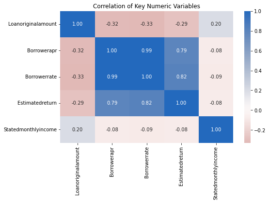

```python
numeric_var = ['Loanoriginalamount', 'Borrowerapr', 'Borrowerrate', 'Estimatedreturn', 'Statedmonthlyincome']

# Correlation plot
plt.figure(figsize = [8, 5])
sb.heatmap(loan[numeric_var].corr(), annot = True, fmt = '.2f',
          cmap = 'vlag_r', center = 0)
plt.title('Correlation of Key Numeric Variables')
plt.show()
```

#### Observations:

- A high and positive correlation is observed between Estimated return, borrower rate and borrower apr
- A negative or low correlation was observed for loan original amount and stated monthly income across estimated return, borrowe rate and borrower apr

### 2. QUANTITATIVE VS QUALITATIVE

#### A. Loan Original Amount vs Term

> What relationship exists between loan original amount and term?

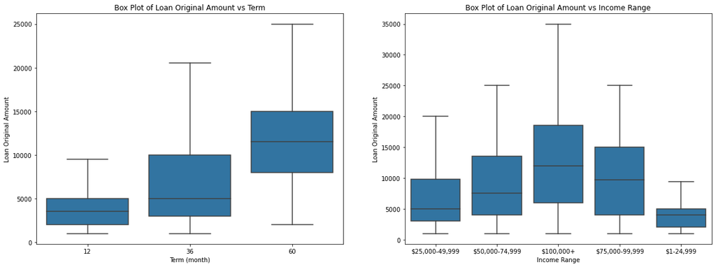

```python
plt.figure(figsize = [20, 7])


plt.subplot(1, 2, 1)
sb.boxplot(data = loan, x = 'Term', y = 'Loanoriginalamount', color = base_color, showfliers = False);
plt.xlabel('Term (month)')
plt.ylabel('Loan Original Amount')
plt.title('Box Plot of Loan Original Amount vs Term');

plt.subplot(1, 2, 2)
sb.boxplot(data = loan, x = 'Incomerange', y = 'Loanoriginalamount', color = base_color, showfliers = False);
plt.xlabel('Income Range')
plt.ylabel('Loan Original Amount')
plt.title('Box Plot of Loan Original Amount vs Income Range');
```

#### Observations:

- There is a clear relationship between loan original amount vs term and loan original amount vs Income Range
- Loan original amount increased as the term of the loan increased
- The median of loan original amount increased marginally from 12 to 36 months but a significant increase occured from 36 to 60 months.
- The highest income range appeared to take the highest loan while the lowest income range had the least loan original amount

### Estimated Return vs Prosper Score

> What is the distribution of the estimated return across the various prosper score?

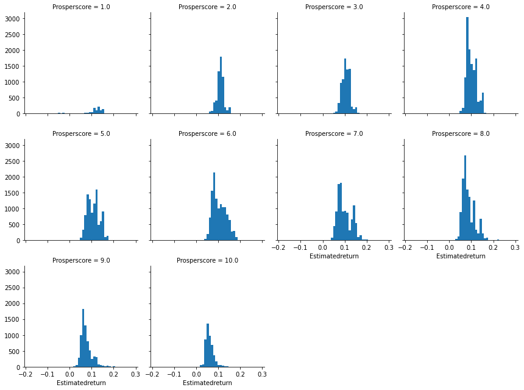

```python
# Facet Grid

plt.figure(figsize = [20, 5])
bin7 = np.arange(loan['Estimatedreturn'].min(), loan['Estimatedreturn'].max()+0.01, 0.01)
g = sb.FacetGrid(data = loan, col = 'Prosperscore', col_wrap = 4)
g.map(plt.hist, 'Estimatedreturn', bins = bin7);
```

### 3. QUALITATIVE VS QUALITATIVE

#### A. Distribution of Loan Status across the Income Ranges

> What is the distribution of the loan status across the various income ranges?

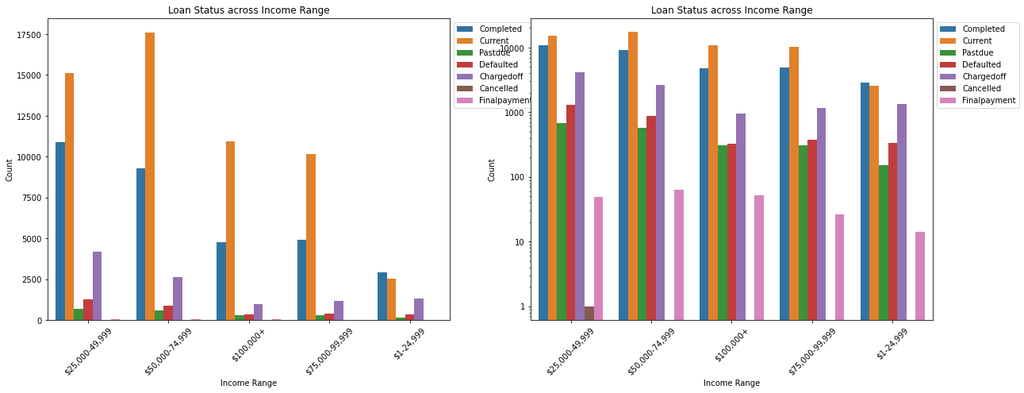

```python
plt.figure(figsize = [20,7])

# Normal Chart
plt.subplot(1,2,1)
sb.countplot(data = loan, x = 'Incomerange', hue = 'Loanstatus');
plt.xticks (rotation = 45)
plt.xlabel('Income Range')
plt.ylabel ('Count')
plt.title('Loan Status across Income Range')
plt.legend(bbox_to_anchor=(1.0, 1.0));

# Scale transformed Chart
plt.subplot(1,2,2)
sb.countplot(data = loan, x = 'Incomerange', hue = 'Loanstatus');

plt.yscale('log')
tick = [1, 10, 100, 1000, 10000]
label = ['{}'.format (v) for v in tick]
plt.yticks(tick, label)
plt.xticks (rotation = 45)
plt.xlabel('Income Range')
plt.ylabel ('Count');
plt.title('Loan Status across Income Range')
plt.legend(bbox_to_anchor=(1.0, 1.0));
```

#### B. Dsitribution of loan status across Prosper Rating (Alpha)

> How is the loan status distributed across Prosper rating (alpha)?

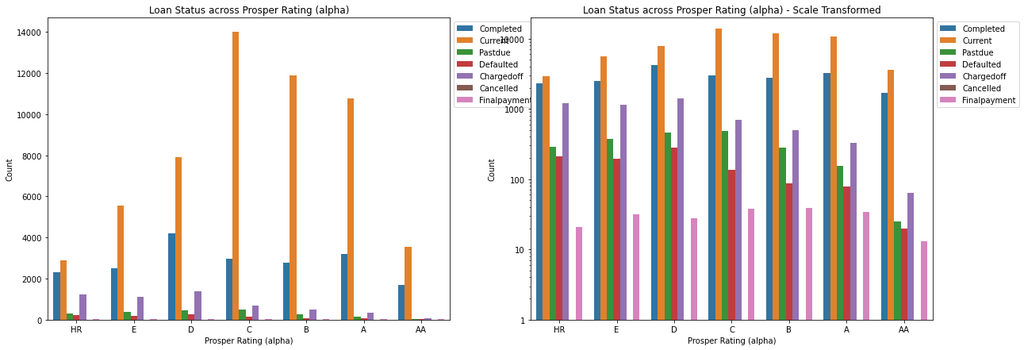

```python
plt.figure(figsize = [20,7])

# Normal Chart
plt.subplot(1,2,1)
sb.countplot(data = loan, x = 'Prosperrating (alpha)', hue = 'Loanstatus');
plt.xlabel('Prosper Rating (alpha)')
plt.ylabel ('Count')
plt.title('Loan Status across Prosper Rating (alpha)')
plt.legend(bbox_to_anchor=(1.0, 1.0));

# Scale transformed Chart
plt.subplot(1,2,2)
sb.countplot(data = loan, x = 'Prosperrating (alpha)', hue = 'Loanstatus');

plt.yscale('log')
tick = [1, 10, 100, 1000, 10000]
label = ['{}'.format (v) for v in tick]
plt.yticks(tick, label)
plt.xlabel('Prosper Rating (alpha)')
plt.ylabel ('Count');
plt.title('Loan Status across Prosper Rating (alpha) - Scale Transformed')
plt.legend(bbox_to_anchor=(1.0, 1.0));
```

#### Observations:

- The current loan status was the highest across all ratings
- The current loan status was close to the completed loan status for rating HR while this isn't the case for all other ratings

### Talk about some of the relationships you observed in this part of the investigation. How did the feature(s) of interest vary with other features in the dataset?

> 1. There is a direct relationship between the income range, term and loan original amount. The loan original amount increased as the term and income range increased.
> 2. Borrower rate and borrower api have direct relationship
> 3. Unlike the relationship discussed above, there was no clear relationship between loan original amount and borrower apr as well as borrower rate. Further exploration will be needed to help understand the relationship

## Multivariate Exploration

> Create plots of three or more variables to investigate your data even further. Make sure that your investigations are justified, and follow from your work in the previous sections.

#### A. Distribution of Estimated Return and Borrower APR by Loan Status and Term

> How does borrower rate and borrower apr affect the distribution of estimated return?

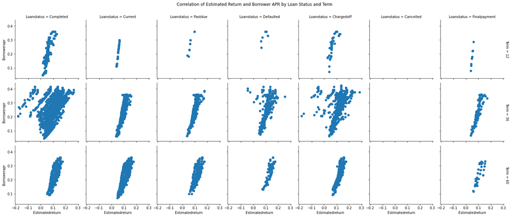

```python
g = sb.FacetGrid(data = loan, col = 'Loanstatus', row = 'Term', height = 3,
                margin_titles = True)
g.map(plt.scatter, 'Estimatedreturn', 'Borrowerapr');

g.fig.suptitle('Correlation of Estimated Return and Borrower APR by Loan Status and Term');
g.fig.subplots_adjust(top = 0.9);
```

#### Observations:

- Negative returns were abserved for loans that lasted for 36 months duration and particularly the ones that have either been completed or charged off
- The highest borrower apr was observed for loans within the 36 months duration which is a positive sign for investment

#### B. Distribution of Estimated Return and Loan Original Amount by Term

> How does the distribution of estimated return and loan original amount look like when assessed by the loan term?

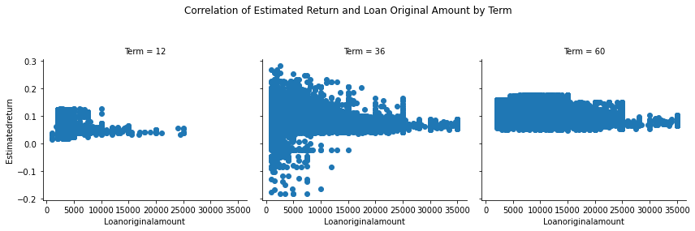

```python
g = sb.FacetGrid(data = loan, col = 'Term', height = 4)
g.map(plt.scatter, 'Loanoriginalamount', 'Estimatedreturn');

g.fig.suptitle('Correlation of Estimated Return and Loan Original Amount by Term');
g.fig.subplots_adjust(top = 0.75);
```

#### Observations:

- The relationship is different across the three terms
- Negative retunrs were seen for some transaction with 36 months term duration which is not good for business.
- The highest estimated return was also observed for some transaction with 36 months duration but this declined continuously as the loan original amount increased

### Talk about some of the relationships you observed in this part of the investigation. Were there features that strengthened each other in terms of looking at your feature(s) of interest?

> 1. Negtaive estimated returns were observed for loans in the 36 months duration. This suggests that additional investigation should be done before investing for this duration. On the otherside, there were no negative estimated returns for 12 or 60 months duration
> 2. Estimated return was highest for completed loans in the 36 months category compared to the other 2 durations

### Were there any interesting or surprising interactions between features?

> Loans within the 36 months category has varying characteristics of a loan; while more loans have been completed, it also had the highest number of defaulters

## Conclusions

> It is interesting to note that high loan original amount does not guarantee high estimated amount which is the general perception. This is supported by loans in each category of the loan duration; high estimated return was observed for lesser loan original amount and vice versa.

## Limitations

> The major limitations are;
> 1. The loan dataset has a total of 81 variables but only 12 were utilized which limited the amount of information we could use
> 2. Detailed data cleaning could not be done because the number of features. For example, dropping unwanted features may affect the variables of interest